# Put Down-and-In Option

Bartlomiej Kowalczuk 372926

I am considering a European style down-and-in put option with a barrier active between the moment of pricing and the option expiry.

In Put Down-and-In option we want the price to decrease and reach the barrier to activate, if the price does not drop to the barrier level, the option never becomes active and expires worthless.

In this simulation i set the barrier to be equal to 85 - not too small but small enough to obtain some interesting results.

### Install package and load library

This library consists of one C++ function for Monte Carlo simulation.

```r
if (!require("BKput")) install.packages("BKput.zip", type = "binaries", repos = NULL)
library(blawok)
```

Build functions for simulations:

```r
getPutPriceExp <- function(expiry) {
   return(getPutDownAndIn(nInt = 3000, Expiry = expiry, nReps = 100))
}

getPutPriceVol <- function(Volatility) {
   return(getPutDownAndIn(nInt = 3000, Vol = Volatility, nReps = 100))
}
```

I set number of repetitions to 100 and the size of single path to 3000.

First of all we want to check how the option behaves on different time to maturity levels.

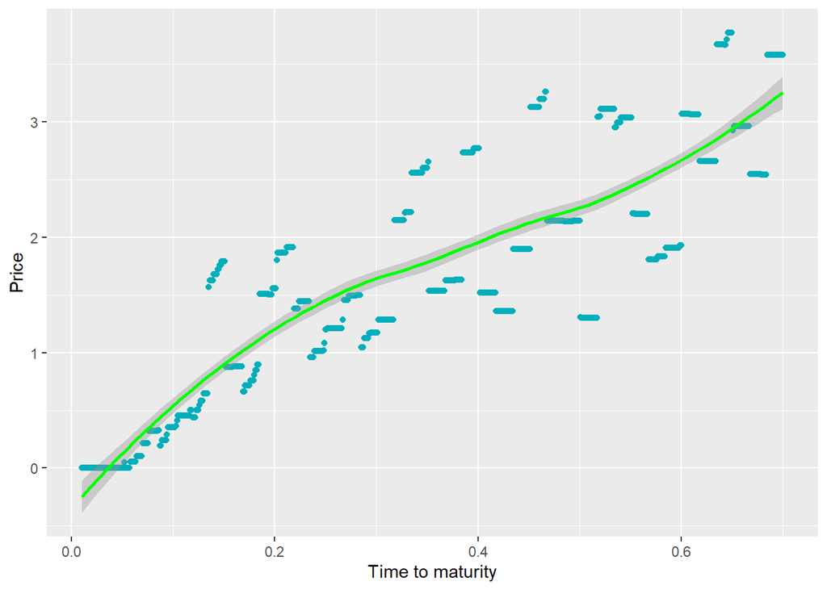

```r
expiry <- seq(0.01, 0.7, by = 0.001)
resultE <- sapply(expiry, getPutPriceExp)

df <- data.frame(expiry,resultE)
p <- ggplot(df, aes(x=expiry, y=resultE))
p + geom_point(color = "#00AFBB") +
  geom_smooth(color = "green") +
  xlab("Time to maturity") +
  ylab("Price")
```

We want the price to reach the barrier, so we want the time to maturity to be as high as possible. It is a positive relation so we can say with confidence that the higher the time to maturity the higher the price can get.

Next, we will check how the option price behaves on differnet volatility levels.

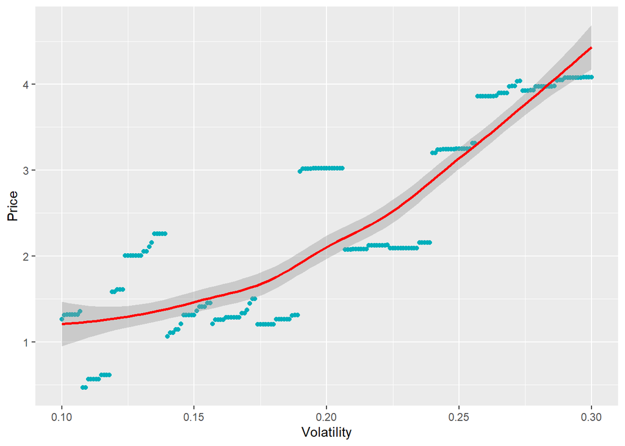

```r
Vol <- seq(0.1, 0.3, by = 0.001)
resultV <- sapply(Vol, getPutPriceVol)

df <- data.frame(Vol,resultV)
p <- ggplot(df, aes(x=Vol, y=resultV))
p + geom_point(color = "#00AFBB") +
  geom_smooth(color = "red") +
  xlab("Volatility") +
  ylab("Price")
```

How would the relation look if we investigate it using both factors simultaneously?

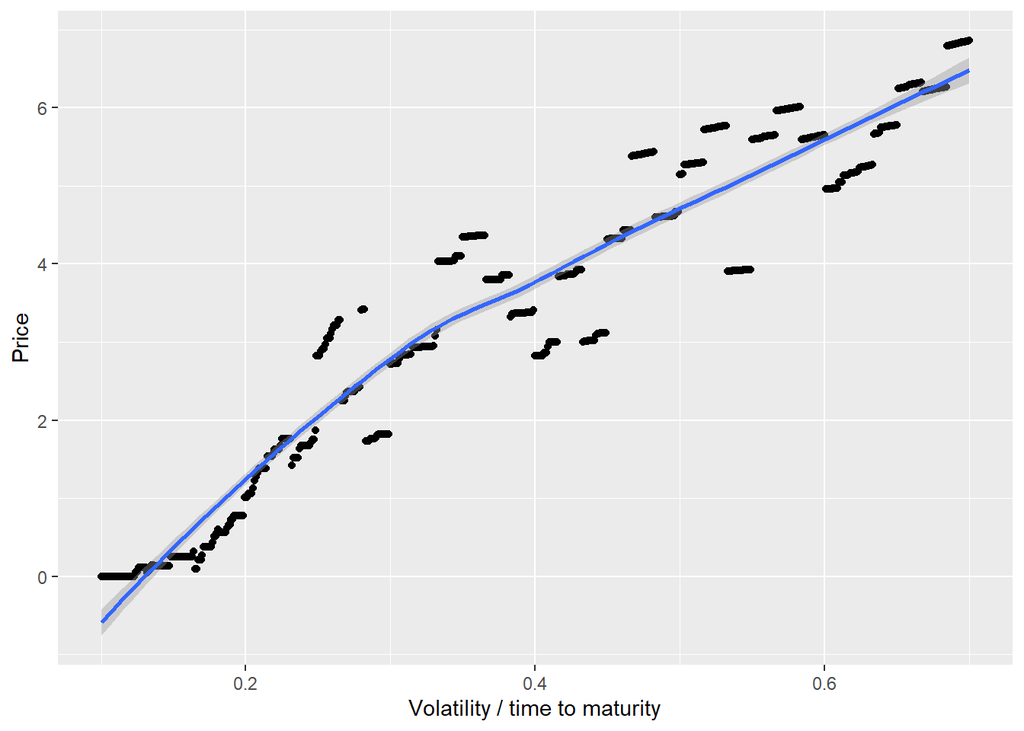

```r
getPutPriceVolExp <- function(vol, exp) {
  return(getPutDownAndIn(nInt = 3000, Vol = vol, Expiry = exp, nReps = 100))
}

Vol <- seq(0.1, 0.7, by = 0.001)
expiry <- seq(0.1, 0.7, by = 0.001)
result_combined <- mapply(getPutPriceVolExp,Vol,expiry)
df <- data.frame(Vol,expiry,result_combined)
p <- ggplot(df, aes(x=Vol, y=result_combined))
p + geom_point() +
  geom_smooth() +
  xlab("Volatility / time to maturity") +
  ylab("Price")
```

We can see a fine growing track of the price as the volatility and time to maturity rises.

*In accordance with the Honor Code, I certify that my answers here are my own work, and I did not make my solutions available to anyone else.*